# Git Version Control using RStudio

### Introduction

Version control software is a tool to use when you write code.

As its most basic level, it lets you capture snapshots of your progress, along with any commentary notes you want to record about the development you’ve done so far and why you’ve done it that way.

It keeps a record of all of the changes to individual lines of code, so you can easily see what changed between snapshots. These snapshots are called ‘commits’ and can be seen as stepping stones along the journey you take with your code. You can use version control to branch off in new directions as well as retrace your steps to an earlier commit from your journey.

The gains from using version control with a good workflow is that it will streamline working with your most important collaborator: Future You!

This document aims to gradually introduce you to using version control software with RStudio, over several stages:

Stage 1 - The basics

Stage 2 - Setup Local Version Control in RStudio

Stage 3 - Commits

Stage 4 - Reverts

Stage 5 - Branching

Stage 6 - Default branch naming convention

### Stage 1

**The Basics**

The version control software that nearly everyone uses is called ‘Git’.  
It was created in 2005 by Linus Torvalds. He writes….

> “git” can mean anything, depending on your mood.  
> - random three-letter combination that is pronounceable, and not actually used by any common UNIX command. The fact that it is a mispronunciation of “get” may or may not be relevant.  
> - stupid. contemptible and despicable. simple. Take your pick from the dictionary of slang.  
> - “global information tracker”: you’re in a good mood, and it actually works for you. Angels sing, and a light suddenly fills the room.  
> - “goddamn idiotic truckload of sh*t”: when it breaks  
> This is a stupid (but extremely fast) directory content manager. It doesn’t do a whole lot, but what it *does* do is track directory contents efficiently.

So **Git** is version control software that saves a local copy of your files on your laptop that you can work on, and save snapshots.

**GitHub** is a website that is a remote storage location for git files that several people can access. You can upload your collection of local snapshots to GitHub so that other people can see the journey you’ve been on. In addition, other people can retrieve your work from GitHub, look over it, and make suggestions and changes. that you can then merge in with your own original code, if you agree with them.

**GitHub Desktop** is a friendly user-interface that allows Git commands to be easily processed to align with GitHub. It’s bit like how RStudio Desktop is a nicer front end to using just a single R console, and an alternative to RStudio Cloud (or Posit Cloud as it’s now known).

There are other website based tools such as **GitLab** and **Bitbucket** that are alternatives to **GitHub**. By way of a helpful analogy, consider an email message. An email is a thing that can be accessed by using Outlook or Gmail or Apple Mail, etc. Each of these pieces of software are ways of managing, storing and reading emails. And so **Git** is like an email, and **GitHub** is like Outlook, **Gitlab** is like Gmail and **BitBucket** is like Apple Mail.

In this short guide, we are not going to end up using **GitHub**. Instead, it will help you start to use Git locally on your own computer. Once you are comfortable with that, you can then consider using a site like **GitHub** to remotely store your code, for others to see and work with.

RStudio has built into it a nice user interface (UI) that allows the most basic tools of Git to be quite easy to use. This is where we shall start.

- Version control is a way to keep a detailed history of all the files contained in a folder.
- One can go back and forth along the timeline of a project to revert changes and identify which changes were done at a given point in time.
- It is also possible at any point to branch from the main timeline and create a side track along which one can test ideas and write some code without affecting the master (or main) branch.
- Once a branch is mature, it can be merged back into the master (or main) branch, or it can be entirely discarded without having had any effect on the master (or main) branch if it turned out that the tested idea was not so great after all.

### 2

**Setup Local Version Control in RStudio**

In order to start using version control in Rstudio, we have to do some configuration the first time. You only need to do this configuration once.

First of all, we need to tell RStudio where to find the Git software that’s already on your laptop.

1. Go to `Tools > Global Options`.
2. Click on `Git/SVN`.
3. Check *Enable version control interface for RStudio projects*.
4. If required, use the Browse button to navigate to the Git executable file that should already be on your laptop. (see image, below).

[figure not shown]

5. Click the ‘OK’ button.

Now we have 3 options for how to enable Git with our coding project, and they depend upon what you have already got in place in terms of projects, folders and files.

Situation 1 - You have no existing folders or files.

Situation 2 - You have a folder or file already, but not a project.

Situation 3 - You have an R project already.

#### No existing folders or files

You will need to create a project first, to enable Git version control on it.

1. Go to `File \> New Project... \> New Directory \> New Project`.
2. Type in Directory name and any subdirectory.
3. Make sure that the `Create a Git repository` is ticked.
4. Click on `Create Project`.

You should now have a new, empty project.

In the same panel as Environment, etc, you should now see an extra tab called ‘Git’.

#### Have files or folders, but no R project.

You will need to create a project that contains your existing files, so that Git version control can be used with your collection of files and folders.

1. Go to `File \> New Project... \> Existing Directory`.
2. Browse to the folder containing your files.
3. Click on `Create Project`.

You should now have a project that contains your existing files.

In the same panel as Environment, etc, you should now see an extra tab called ‘Git’.

#### Have R project but no version control.

You will just need to enable Git version control with the project.

1. Either use the menu to select `Tools \> Project Options ...`

   Or click on the .Rproj file in your Files Pane
2. With the Project Options dialog window that appears, click on `Git/SVN`.
3. Next to `Version control system`, select `Git`.

[figure not shown]

   Enable Git version control on your existing project

4. Click the OK button.

You will likely have to restart your R session, so agree to do this.

You should now have a project that has Git version control enabled.

In the same panel as Environment, etc, you should now see an extra tab called ‘Git’.

### 3

**Commits**

In the following tutorials, you will see mention of a Secure Hash Algorithm (or SHA) number. This is what Git uses to uniquely identify all file objects and commits, and it is derived from the very contents of those files.

If you are interested, you can read more about SHA [here](https://www.designveloper.com/blog/hash-values-sha-1-in-git/).

All of the information that Git stores is put in a hidden folder called `.git` that is in the same folder location as the `.Rproj` project file. If you really want to see that folder, you need to tick the checkbox in: `Windows File Manager > View > Hidden Items`.

**Note:** the following links take you to an external website that contains screenshot images from an earlier version of RStudio Desktop. You may see some screenshots and references to `Shell...` which can be considered to be the same as `New Terminal...` in the current version of Rstudio Desktop.

[Tracking files and committing changes (Read: 5 mins)](https://matthieu-bruneaux.gitlab.io/guide-r-rstudio-git-gitlab/020-intro-version-control.html#tracking-files-and-committing-changes)

[Viewing the History of commits (Read: 3 mins)](https://matthieu-bruneaux.gitlab.io/guide-r-rstudio-git-gitlab/020-intro-version-control.html#viewing-the-history)

[Ignoring files (Read: 3 mins)](https://matthieu-bruneaux.gitlab.io/guide-r-rstudio-git-gitlab/020-intro-version-control.html#ignoring-files)

You are recommended to stop for a while at this stage, and use all that you have learnt so far in a few projects.

This will help you to gain practice at the routine of committing at regular intervals, along with some commentary of **why** you made whatever changes you made.

There will then come the time when you wish to ‘undo’ some changes you’ve made, or to go exploring in a new direction. That’s what Stage 4 and Stage 5 will cover.

### 4

**Reverts**

This is the first Git process where you will have to type code into Terminal, as RStudio does not have buttons to action this process. RStudio is not likely to include them in the future either.

[Reverting changes (Read: 10 mins)](https://matthieu-bruneaux.gitlab.io/guide-r-rstudio-git-gitlab/020-intro-version-control.html#reverting-changes)

Some code you may therefore use is given below:

To look at an earlier commit:

`git checkout 1f2f3f4f` [where 1f2f3f4f is the SHA code of an earlier commit]

To start working on a new branch stem, from that earlier commit:

`git checkout -b new_branch_name`

To return to the head of the `main` branch, and carry on:

`git checkout main`

To revert just one file to an older state, but not all the project:

`git checkout 1f2f3f4f -- hello.R` [the two dashes separate the commit SHA from the file name]

To un-stage all files, which is a quick way of un-checking all the `Staged` tick boxes:

`git reset`

### 5

**Branching**

[Happy Git with R](https://happygitwithr.com/git-branches) says that ….

Branching means that you take a detour from the main stream of development and do work without changing the main stream. It allows one or many people to work in parallel without overwriting each other’s work. It allows a someone working solo to work incrementally on an experimental idea, without jeopardizing the state of the main product.

Branching in Git is very lightweight, which means creating a branch and switching between branches is nearly instantaneous. This means Git encourages workflows which create small branches for exploration or new features, often merging them back together quickly.

**Note** the screen shots on the website page show the central branch to be named as `master` but in your version of RStudio desktop, it might be called `main`. This issue is resolved in Stage 6 of this guide, but for the moment, just work with the one that your RStudio software has on show.

[Branching and Merging (read: 10 mins)](https://matthieu-bruneaux.gitlab.io/guide-r-rstudio-git-gitlab/020-intro-version-control.html#branching-and-merging)

And if you wanted to travel back in time through your git commit history, with the goal of returning to a previous commit, creating a branch, and then moving forward on that branch to create a new development code, then this link is for you:

[Going back in your Commit History with RStudio (Video: 19 mins)](https://youtu.be/Y9h-1u6uQ6c)

### 6

**Default branch naming convention**

To ensure compatability between RStudio and any future remote repository that you might use, we need to rename the default branch of `master` to `main`.

However, if you already have a populated local repository which has branches, then renaming `master` to `main` may not be suitable, or could generate errors. This therefore points to renaming your default branches at the very outset of starting a new project, before any commits are made or branches created.

To do the renaming from `master` to `main`, in Rstudio’s terminal window, type the following:

`git branch -m master main`

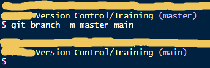

To change the default branch name within your local version of Git to `main`, so that all future RStudio Projects start off with this configuration, then type the following into the Terminal:

`git config --global init.defaultBranch main`

This name change is in keeping with many [companies’ efforts](https://www.zdnet.com/article/github-to-replace-master-with-main-starting-next-month/) to remove unnecessary references to slavery and to replace them with more inclusive terms.

To read more about renaming default branches visit this [Tidyverse blog](https://www.tidyverse.org/blog/2021/10/renaming-default-branch/).